# R-Ladies Workshop - Modeling

Divya and Elisa

2nd October 2019

## The Happiness Data 2016

Today we look at the Happiness Data from the WHO.

```r
Happiness_2016 <- read.csv("Happiness_2016.csv")
```

# 1. Look at the data

What parameters do you see? What questions can we address using these factors.

Let’s look at Trust in government in a bit more detail.

Q - What kind of variable is this? Q - Can you plot to see its relation to Happiness?

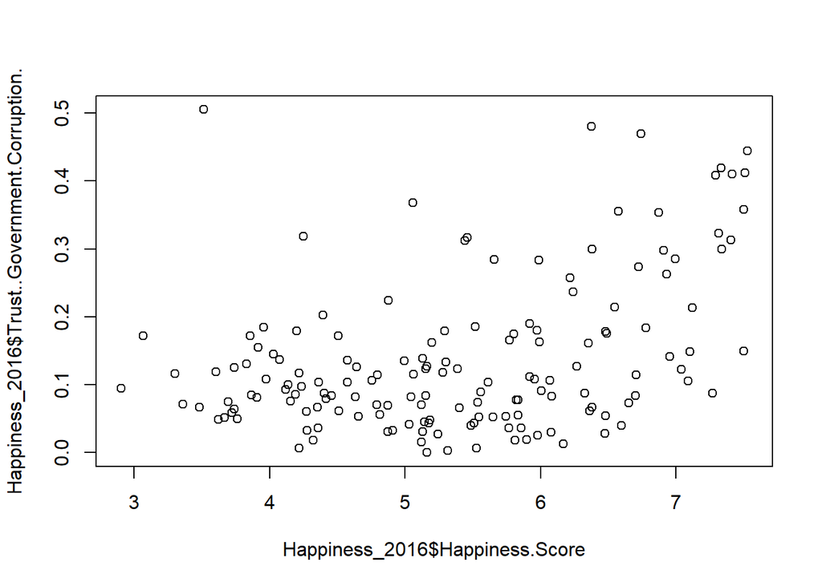

```r
plot(Happiness_2016$Happiness.Score, Happiness_2016$Trust..Government.Corruption.)
```

# 2. Let’s try some models

Q - Does Corruption within the government predict happiness of its citizens?

Q - How can we add Freedom as a preictor to the model?

Q - What is the difference between adding factors and looking at their interactions?

```r
## ANSWERS


#fit our regression model
RegressionModel <- lm(Happiness.Score ~ Trust..Government.Corruption., # regression formula
              data=Happiness_2016) # data set
# Summarize and print the results
summary(RegressionModel) # show regression coefficients table
```

```
##
## Call:
## lm(formula = Happiness.Score ~ Trust..Government.Corruption.,
##     data = Happiness_2016)
##
## Residuals:
##     Min      1Q  Median      3Q     Max
## -3.3867 -0.7337  0.0653  0.8163  2.0929
##
## Coefficients:
##                               Estimate Std. Error t value Pr(>|t|)
## (Intercept)                     4.8133     0.1335  36.042  < 2e-16 ***
## Trust..Government.Corruption.   4.1336     0.7562   5.466  1.8e-07 ***
## ---
## Signif. codes:  0 '***' 0.001 '**' 0.01 '*' 0.05 '.' 0.1 ' ' 1
##
## Residual standard error: 1.049 on 155 degrees of freedom
## Multiple R-squared:  0.1616, Adjusted R-squared:  0.1562
## F-statistic: 29.88 on 1 and 155 DF,  p-value: 1.798e-07
```

```r
RegressionModel2 <- lm(Happiness.Score ~ Trust..Government.Corruption. + Freedom,
                      data=Happiness_2016)
summary(RegressionModel2)
```

```
##
## Call:
## lm(formula = Happiness.Score ~ Trust..Government.Corruption. +
##     Freedom, data = Happiness_2016)
##
## Residuals:
##      Min       1Q   Median       3Q      Max
## -3.12005 -0.75060  0.08456  0.70370  1.99165
##
## Coefficients:
##                               Estimate Std. Error t value Pr(>|t|)
## (Intercept)                     3.7395     0.2047  18.270  < 2e-16 ***
## Trust..Government.Corruption.   1.6146     0.7785   2.074   0.0397 *
## Freedom                         3.8288     0.5940   6.445 1.41e-09 ***
## ---
## Signif. codes:  0 '***' 0.001 '**' 0.01 '*' 0.05 '.' 0.1 ' ' 1
##
## Residual standard error: 0.9337 on 154 degrees of freedom
## Multiple R-squared:  0.3397, Adjusted R-squared:  0.3312
## F-statistic: 39.62 on 2 and 154 DF,  p-value: 1.313e-14
```

```r
RegressionModel3 <- lm(Happiness.Score ~ Trust..Government.Corruption. * Freedom,
                       data=Happiness_2016)
summary(RegressionModel3)
```

```
##
## Call:
## lm(formula = Happiness.Score ~ Trust..Government.Corruption. *
##     Freedom, data = Happiness_2016)
##
## Residuals:
##     Min      1Q  Median      3Q     Max
## -3.4328 -0.6808  0.1590  0.6513  2.0290
##
## Coefficients:
##                                       Estimate Std. Error t value Pr(>|t|)
## (Intercept)                             4.6015     0.3507  13.119  < 2e-16
## Trust..Government.Corruption.          -7.0035     2.9817  -2.349  0.02011
## Freedom                                 1.8776     0.8728   2.151  0.03303
## Trust..Government.Corruption.:Freedom  17.7259     5.9306   2.989  0.00326
##
## (Intercept)                           ***
## Trust..Government.Corruption.         *
## Freedom                               *
## Trust..Government.Corruption.:Freedom **
## ---
## Signif. codes:  0 '***' 0.001 '**' 0.01 '*' 0.05 '.' 0.1 ' ' 1
##
## Residual standard error: 0.9105 on 153 degrees of freedom
## Multiple R-squared:  0.3762, Adjusted R-squared:  0.3639
## F-statistic: 30.75 on 3 and 153 DF,  p-value: 1.293e-15
```

There are a number of different Parametric and non-parametric tests we can try in the same format. Instead of lm, we could use t.test(), aov(), wilcox.test(), kruskal.test().

Is there a categorical variable we can use to run an ANOVA on?

Q - How does the happiness quoatient differ based on regions?

```r
ANOVA <- aov(Happiness.Score ~ Region,
             data=Happiness_2016)
summary(ANOVA)
```

```
##              Df Sum Sq Mean Sq F value Pr(>F)
## Region        9 126.69  14.077      27 <2e-16 ***
## Residuals   147  76.64   0.521
## ---
## Signif. codes:  0 '***' 0.001 '**' 0.01 '*' 0.05 '.' 0.1 ' ' 1
```

```r
TukeyHSD(ANOVA)
```

```
##   Tukey multiple comparisons of means
##     95% family-wise confidence level
##
## Fit: aov(formula = Happiness.Score ~ Region, data = Happiness_2016)
##
## $Region
##                                                                    diff
## Central and Eastern Europe-Australia and New Zealand        -1.95281034
## Eastern Asia-Australia and New Zealand                      -1.69933333
## Latin America and Caribbean-Australia and New Zealand       -1.22175000
## Middle East and Northern Africa-Australia and New Zealand   -1.93744737
## North America-Australia and New Zealand                     -0.06950000
## Southeastern Asia-Australia and New Zealand                 -1.98461111
## Southern Asia-Australia and New Zealand                     -2.76021429
## Sub-Saharan Africa-Australia and New Zealand                -3.18707895
## Western Europe-Australia and New Zealand                    -0.63783333
## Eastern Asia-Central and Eastern Europe                      0.25347701
## Latin America and Caribbean-Central and Eastern Europe       0.73106034
## Middle East and Northern Africa-Central and Eastern Europe   0.01536298
## North America-Central and Eastern Europe                     1.88331034
## Southeastern Asia-Central and Eastern Europe                -0.03180077
## Southern Asia-Central and Eastern Europe                    -0.80740394
## Sub-Saharan Africa-Central and Eastern Europe               -1.23426860
## Western Europe-Central and Eastern Europe                    1.31497701
## Latin America and Caribbean-Eastern Asia                     0.47758333
## Middle East and Northern Africa-Eastern Asia                -0.23811404
## North America-Eastern Asia                                   1.62983333
## Southeastern Asia-Eastern Asia                              -0.28527778
## Southern Asia-Eastern Asia                                  -1.06088095
## Sub-Saharan Africa-Eastern Asia                             -1.48774561
## Western Europe-Eastern Asia                                  1.06150000
## Middle East and Northern Africa-Latin America and Caribbean -0.71569737
## North America-Latin America and Caribbean                    1.15225000
## Southeastern Asia-Latin America and Caribbean               -0.76286111
## Southern Asia-Latin America and Caribbean                   -1.53846429
## Sub-Saharan Africa-Latin America and Caribbean              -1.96532895
## Western Europe-Latin America and Caribbean                   0.58391667
## North America-Middle East and Northern Africa                1.86794737
## Southeastern Asia-Middle East and Northern Africa           -0.04716374
## Southern Asia-Middle East and Northern Africa               -0.82276692
```

[output cut: 135 more lines]

```
## North America-Middle East and Northern Africa               0.0224810
## Southeastern Asia-Middle East and Northern Africa           1.0000000
## Southern Asia-Middle East and Northern Africa               0.2380242
## Sub-Saharan Africa-Middle East and Northern Africa          0.0000003
## Western Europe-Middle East and Northern Africa              0.0000030
## Southeastern Asia-North America                             0.0294290
## Southern Asia-North America                                 0.0003101
## Sub-Saharan Africa-North America                            0.0000008
## Western Europe-North America                                0.9873720
## Southern Asia-Southeastern Asia                             0.5086390
## Sub-Saharan Africa-Southeastern Asia                        0.0005847
## Western Europe-Southeastern Asia                            0.0002694
## Sub-Saharan Africa-Southern Asia                            0.9133646
## Western Europe-Southern Asia                                0.0000000
## Western Europe-Sub-Saharan Africa                           0.0000000
```

# 3. Let’s think about the independence of the data

Q -

- 1. Do you think that countries in the same region tend to be more simmilar to each other? If your anser is yes, then the countries are not relly independent and identically distributed data. This could be a problem with statistical models. So you have three options:
1. Ignore the prblem, or argue why you think yout data IS independent (you will no be the only one)
2. Do not ignore it, take the average of each region and then make a model using this average. Yes, what you think is correct, you loose a lot of data!
3. Do one linear model for each region…data costly (e.g. Australia and North America have only two data points)
4. Try a linear mixed model
- 2. How variable is the happiness between regions?
- 3. How does happyness depend on other predictors such as health, economy and generosity?

### Some more visualization of the data

We can do some plots to see how data look like. In this plot we visualize how economy affect happyness in every region. We could do one plot per predictor.

```r
library(dplyr)
```

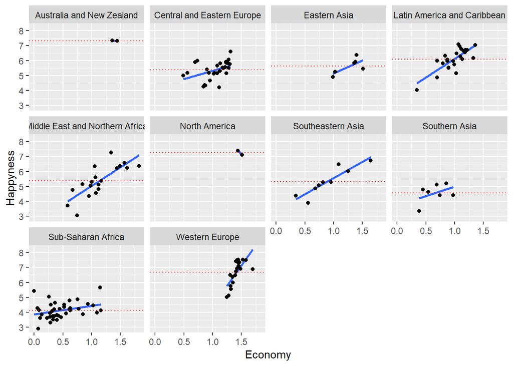

```r
library(tidyr)

Happiness_2016 <- Happiness_2016 %>% group_by(Region) %>% mutate(mean.reg = mean(Happiness.Score)) %>%  ungroup()

library(ggplot2)

ggplot(Happiness_2016) +
  aes(x = Economy..GDP.per.Capita., y = Happiness.Score) +
  stat_smooth(method = "lm", se = FALSE) +
  # Put the points on top of lines
  geom_point() +
  facet_wrap("Region") +
  labs(x = "Economy", y = "Happyness") +
  geom_hline(aes(yintercept = mean.reg), colour='red', lty="dotted")
```

Given what we see in the data, we can try two different models:

```r
library(lme4)
happy.mixed.model <-  lmer(Happiness.Score ~ Economy..GDP.per.Capita. + Health..Life.Expectancy.+ Generosity + (1|Region), data = Happiness_2016)

summary(happy.mixed.model)
```

```
## Linear mixed model fit by REML ['lmerMod']
## Formula:
## Happiness.Score ~ Economy..GDP.per.Capita. + Health..Life.Expectancy. +
##     Generosity + (1 | Region)
##    Data: Happiness_2016
##
## REML criterion at convergence: 288.4
##
## Scaled residuals:
##     Min      1Q  Median      3Q     Max
## -3.7228 -0.5314  0.0542  0.6596  3.6518
##
## Random effects:
##  Groups   Name        Variance Std.Dev.
##  Region   (Intercept) 0.1295   0.3599
##  Residual             0.3302   0.5746
## Number of obs: 157, groups:  Region, 10
##
## Fixed effects:
##                          Estimate Std. Error t value
## (Intercept)                3.0080     0.2890  10.407
## Economy..GDP.per.Capita.   1.5252     0.2136   7.142
## Health..Life.Expectancy.   1.1030     0.4661   2.367
## Generosity                 1.2551     0.4088   3.070
##
## Correlation of Fixed Effects:
##             (Intr) E..GDP H..L.E
## Ec..GDP..C. -0.217
## Hlth..Lf.E. -0.468 -0.624
## Generosity  -0.415  0.174 -0.118
```

```r
happy.mixed.model.2 <-  lmer(Happiness.Score ~ Economy..GDP.per.Capita. + Health..Life.Expectancy.+ Generosity + (Economy..GDP.per.Capita.|Region), data = Happiness_2016)

summary(happy.mixed.model)
```

```
## Linear mixed model fit by REML ['lmerMod']
## Formula:
## Happiness.Score ~ Economy..GDP.per.Capita. + Health..Life.Expectancy. +
##     Generosity + (1 | Region)
##    Data: Happiness_2016
##
## REML criterion at convergence: 288.4
##
## Scaled residuals:
##     Min      1Q  Median      3Q     Max
## -3.7228 -0.5314  0.0542  0.6596  3.6518
##
## Random effects:
##  Groups   Name        Variance Std.Dev.
##  Region   (Intercept) 0.1295   0.3599
##  Residual             0.3302   0.5746
## Number of obs: 157, groups:  Region, 10
##
## Fixed effects:
##                          Estimate Std. Error t value
## (Intercept)                3.0080     0.2890  10.407
## Economy..GDP.per.Capita.   1.5252     0.2136   7.142
## Health..Life.Expectancy.   1.1030     0.4661   2.367
## Generosity                 1.2551     0.4088   3.070
##
## Correlation of Fixed Effects:
##             (Intr) E..GDP H..L.E
## Ec..GDP..C. -0.217
## Hlth..Lf.E. -0.468 -0.624
## Generosity  -0.415  0.174 -0.118
```

```r
summary(happy.mixed.model.2)
```

```
## Linear mixed model fit by REML ['lmerMod']
## Formula:
## Happiness.Score ~ Economy..GDP.per.Capita. + Health..Life.Expectancy. +
##     Generosity + (Economy..GDP.per.Capita. | Region)
##    Data: Happiness_2016
##
## REML criterion at convergence: 276.9
##
## Scaled residuals:
##     Min      1Q  Median      3Q     Max
## -3.7298 -0.5007  0.0021  0.6491  3.1793
##
## Random effects:
##  Groups   Name                     Variance Std.Dev. Corr
##  Region   (Intercept)              0.09681  0.3111
##           Economy..GDP.per.Capita. 0.42078  0.6487   -0.87
##  Residual                          0.29387  0.5421
## Number of obs: 157, groups:  Region, 10
##
## Fixed effects:
##                          Estimate Std. Error t value
## (Intercept)                2.9115     0.2270  12.824
## Economy..GDP.per.Capita.   1.8639     0.3101   6.010
## Health..Life.Expectancy.   0.6234     0.4415   1.412
## Generosity                 1.0923     0.3895   2.805
##
## Correlation of Fixed Effects:
##             (Intr) E..GDP H..L.E
## Ec..GDP..C. -0.390
## Hlth..Lf.E. -0.323 -0.559
## Generosity  -0.440  0.049 -0.092
```

We do not have p-values here hummm!

```r
library(lmerTest)
# Test significance of random effects
ranova(happy.mixed.model)
```

```
## ANOVA-like table for random-effects: Single term deletions
##
## Model:
## Happiness.Score ~ Economy..GDP.per.Capita. + Health..Life.Expectancy. +
##     Generosity + (1 | Region)
##              npar  logLik    AIC    LRT Df Pr(>Chisq)
## <none>          6 -144.21 300.42
## (1 | Region)    5 -156.36 322.72 24.303  1  8.233e-07 ***
## ---
## Signif. codes:  0 '***' 0.001 '**' 0.01 '*' 0.05 '.' 0.1 ' ' 1
```

```r
#Test significance of fixed effects
ml.happy.mixed.model <- update(happy.mixed.model, REML = FALSE) # this changes the algorith used to fit the model
#Finally we can test significance
anova(as_lmerModLmerTest(ml.happy.mixed.model))
```

```
## Type III Analysis of Variance Table with Satterthwaite's method
##                           Sum Sq Mean Sq NumDF  DenDF F value    Pr(>F)
## Economy..GDP.per.Capita. 16.9971 16.9971     1 152.49 52.3454 2.119e-11
## Health..Life.Expectancy.  1.9558  1.9558     1 138.78  6.0233  0.015356
## Generosity                3.1992  3.1992     1 151.95  9.8524  0.002038
##
## Economy..GDP.per.Capita. ***
## Health..Life.Expectancy. *
## Generosity               **
## ---
## Signif. codes:  0 '***' 0.001 '**' 0.01 '*' 0.05 '.' 0.1 ' ' 1
```

# 4. Recap - Ploting the data in a map

```r
require(rnaturalearth)
require(rnaturalearthdata)
world <- ne_countries(scale = "medium", returnclass = "sf") # this is another function to get polygons of countries.
```

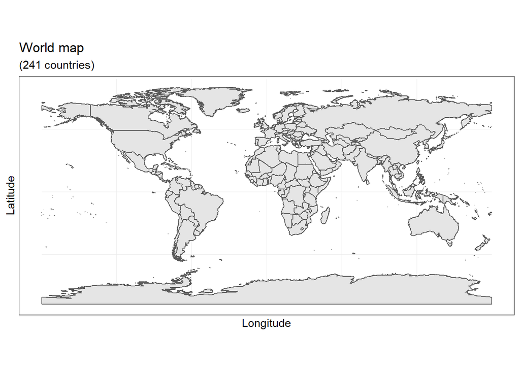

```r
library(ggplot2)

ggplot(data = world) +
    theme_bw()+
    geom_sf() +
    xlab("Longitude") + ylab("Latitude") +
    ggtitle("World map", subtitle = paste0("(", dim(world)[1], " countries)"))
```

```r
#both df woth the same name of the varaible we will use to join
colnames(Happiness_2016)[1] <- "name"

Happiness_GEO <- left_join(world, Happiness_2016, by="name")
```

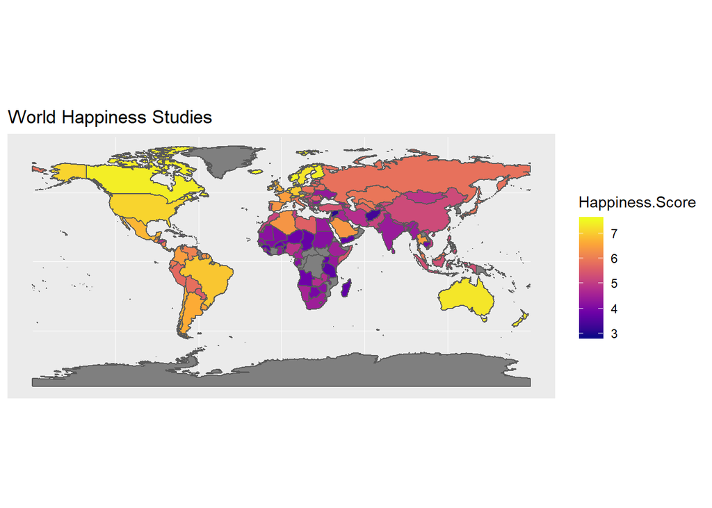

```r
ggplot(data = Happiness_GEO) +
    geom_sf(aes(fill = Happiness.Score )) +
    scale_fill_viridis_c(option = "plasma") +  # this allows you to choose different colour scale
    ggtitle("World Happiness Studies")
```

#### Where is the model working better?

```r
happy.predictions <- predict(happy.mixed.model)

#Expected - Observed
happy.residuasl <-  Happiness_2016$Happiness.Score - happy.predictions # Obaserved - predicted

Happiness_2016$Model.Residuals <- happy.residuasl

Happiness_GEO <- left_join(world, Happiness_2016, by="name")
```

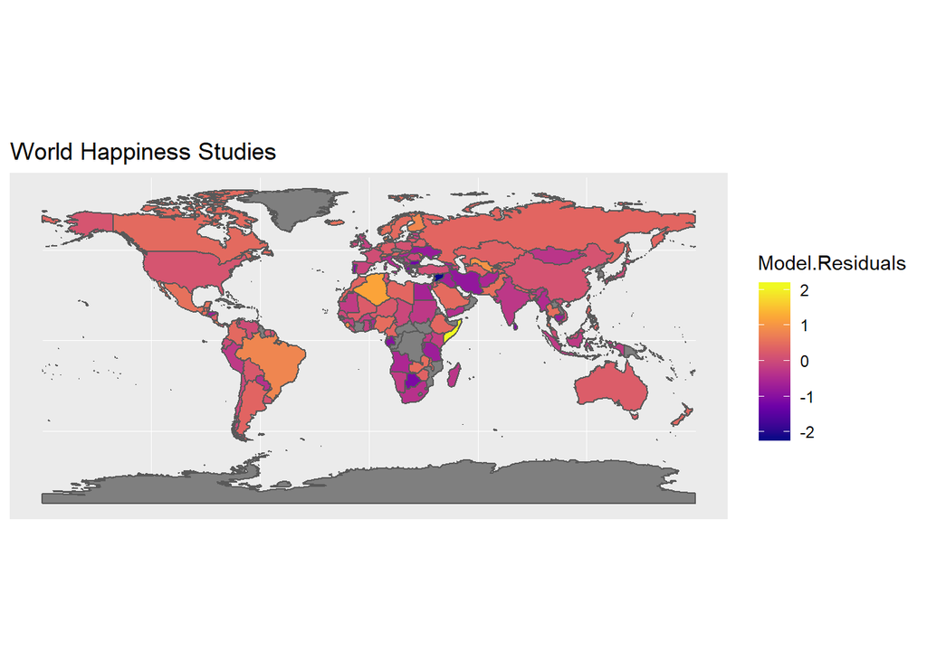

```r
ggplot(data = Happiness_GEO) +
    geom_sf(aes(fill = Model.Residuals )) +
    scale_fill_viridis_c(option = "plasma") +  # this allows you to choose different colour scale
    ggtitle("World Happiness Studies")
```